# Visualização básica de dados

Importando libraries:

[output not shown]

[output not shown]

[output not shown]

Setando o diretório corrente:

```r
setwd(dirname(rstudioapi::getActiveDocumentContext()$path))
getwd()
```

```
[1] "/Users/adrianosastre/Dropbox/Data Science/Exercícios/datascience-exercises-april-13-2020/Parte1-Exercício1"
```

```r
load(file = "us_change.rda")
View(us_change)
```

1. Construa um novo tibble no qual todas as variáveis sejam disponibilizadas em número índice, assumindo valor 100 no primeiro trimestre do ano 2000 (ie 2000Q1 = 100).

Nível número índice:

index2000Q1 = 121

us_change_nivel_numero_indice$Consumption[index2000Q1] <- 100; for(i in 2:length(us_change_nivel_numero_indice$Consumption)){ us_change_nivel_numero_indice$Consumption[i] <- (us_change$Consumption[i]/us_change$Consumption[i-1]) * us_change_nivel_numero_indice$Consumption[i-1] } us_change_nivel_numero_indice$Income[index2000Q1] <- 100; for(i in 2:length(us_change_nivel_numero_indice$Income)){ us_change_nivel_numero_indice$Income[i] <- (us_change$Income[i]/us_change$Income[i-1]) * us_change_nivel_numero_indice$Income[i-1] } us_change_nivel_numero_indice$Production[index2000Q1] <- 100; for(i in 2:length(us_change_nivel_numero_indice$Production)){ us_change_nivel_numero_indice$Production[i] <- (us_change$Production[i]/us_change$Production[i-1]) * us_change_nivel_numero_indice$Production[i-1] } us_change_nivel_numero_indice$Savings[index2000Q1] <- 100; for(i in 2:length(us_change_nivel_numero_indice$Savings)){ us_change_nivel_numero_indice$Savings[i] <- (us_change$Savings[i]/us_change$Savings[i-1]) * us_change_nivel_numero_indice$Savings[i-1] }

us_change_nivel_numero_indice$Unemployment[index2000Q1] <- 100; for(i in 2:length(us_change_nivel_numero_indice$Unemployment)){ us_change_nivel_numero_indice$Unemployment[i] <- (us_change$Unemployment[i]/us_change$Unemployment[i-1]) * us_change_nivel_numero_indice$Unemployment[i-1] }

View(us_change_nivel_numero_indice)

2. Explore a correlação entre as variáveis (nível número índice).

print(us_change_nivel_correl_numero_indice)

```
             Consumption Income Production Savings Unemployment
Consumption         1.00   0.38       0.53   -0.26           NA
Income              0.38   1.00       0.27    0.72           NA
Production          0.53   0.27       1.00   -0.06           NA
Savings            -0.26   0.72      -0.06    1.00           NA
Unemployment          NA     NA         NA      NA            1
```

Taxa de variação - número índice:

index2000Q1 = 121

us_change_taxa_variacao_numero_indice$Consumption[index2000Q1] <- 100; for(i in 2:length(us_change_taxa_variacao_numero_indice$Consumption)){ us_change_taxa_variacao_numero_indice$Consumption[i] <- (1 + us_change$Consumption[i]/100) * us_change_taxa_variacao_numero_indice$Consumption[i-1] } us_change_taxa_variacao_numero_indice$Income[index2000Q1] <- 100; for(i in 2:length(us_change_taxa_variacao_numero_indice$Income)){ us_change_taxa_variacao_numero_indice$Income[i] <- (1 + us_change$Income[i]/100) * us_change_taxa_variacao_numero_indice$Income[i-1] } us_change_taxa_variacao_numero_indice$Production[index2000Q1] <- 100; for(i in 2:length(us_change_taxa_variacao_numero_indice$Production)){ us_change_taxa_variacao_numero_indice$Production[i] <- (1 + us_change$Production[i]/100) * us_change_taxa_variacao_numero_indice$Production[i-1] } us_change_taxa_variacao_numero_indice$Savings[index2000Q1] <- 100; for(i in 2:length(us_change_taxa_variacao_numero_indice$Savings)){ us_change_taxa_variacao_numero_indice$Savings[i] <- (1 + us_change$Savings[i]/100) * us_change_taxa_variacao_numero_indice$Savings[i-1] } us_change_taxa_variacao_numero_indice$Unemployment[index2000Q1] <- 100; for(i in 2:length(us_change_taxa_variacao_numero_indice$Unemployment)){ us_change_taxa_variacao_numero_indice$Unemployment[i] <- (1 + us_change$Unemployment[i]/100) * us_change_taxa_variacao_numero_indice$Unemployment[i-1] }

View(us_change_taxa_variacao_numero_indice)

print(us_change_taxa_variacao_numero_indice_corr)

```
             Consumption Income Production Savings Unemployment
Consumption         1.00   0.38       0.53   -0.26        -0.53
Income              0.38   1.00       0.27    0.72        -0.22
Production          0.53   0.27       1.00   -0.06        -0.77
Savings            -0.26   0.72      -0.06    1.00         0.11
Unemployment       -0.53  -0.22      -0.77    0.11         1.00
```

Qual a diferença entre se calcular a correlação das variáveis em número índice e em taxa de variação?

3. Construa gráficos que contribuam em seu entendimento sobre a dinâmica de cada variável do dataset, bem como as relações entre elas. Assim, por exemplo, como ponto de partida plote gráficos de dispersão conjunta das variáveis, bem como suas evoluções ao longo do tempo. Sinta-se livre para complementar tal caracterização com todo e qualquer arsenal analítico que julgue interessante.

Gráficos de correlação:

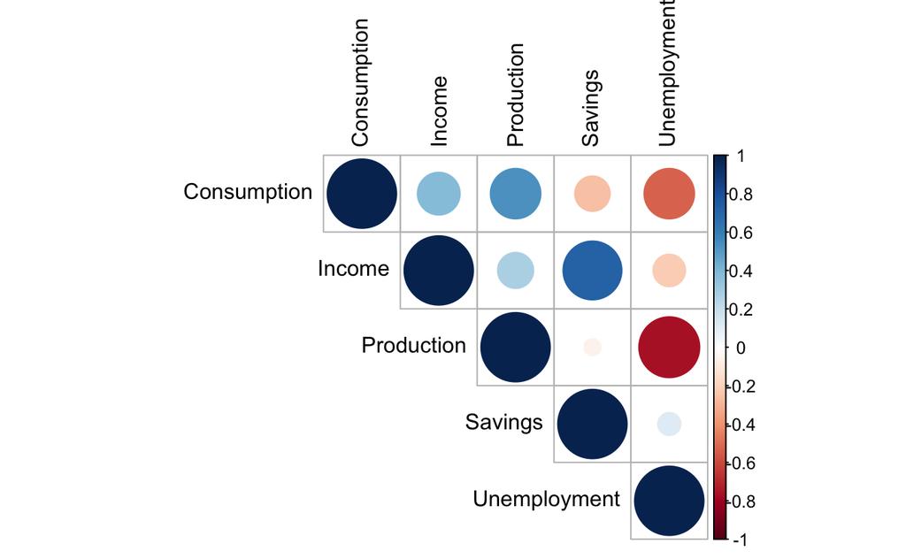

Gráficos de evolução ao longo do tempo (variáveis originais):

[output not shown]

[figure not shown]

Gráficos de evolução ao longo do tempo (variáveis em nível por taxa de variação):

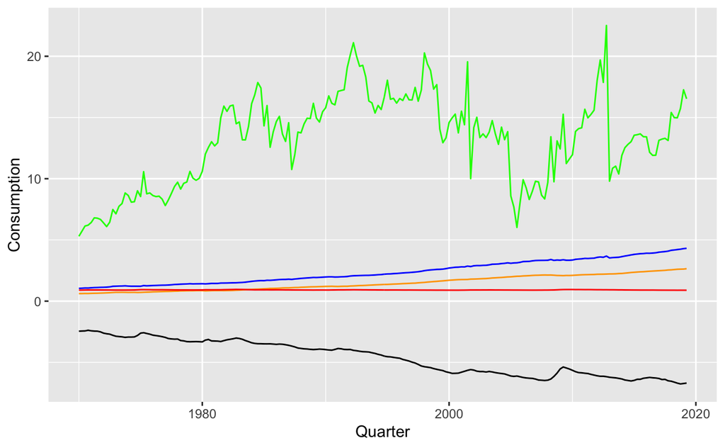

us_change_taxa_variacao_numero_indice %>% tibble::as.tibble() %>% ggplot( aes(x = Quarter, y = Consumption) ) + geom_line()

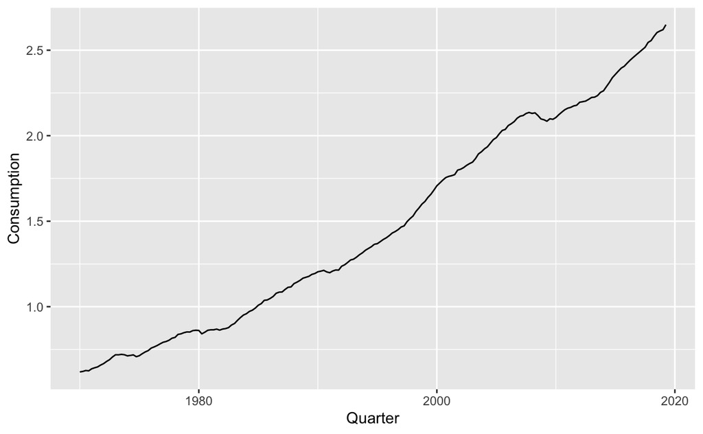

us_change_taxa_variacao_numero_indice %>% tibble::as.tibble() %>% ggplot( aes(x = Quarter, y = Income) ) + geom_line()

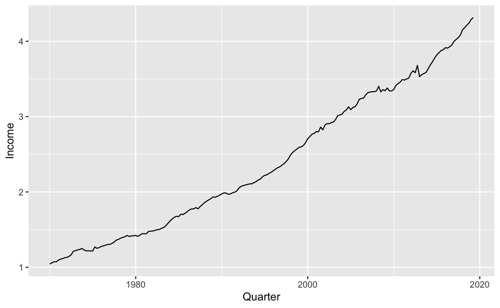

us_change_taxa_variacao_numero_indice %>% tibble::as.tibble() %>% ggplot( aes(x = Quarter, y = Production) ) + geom_line()

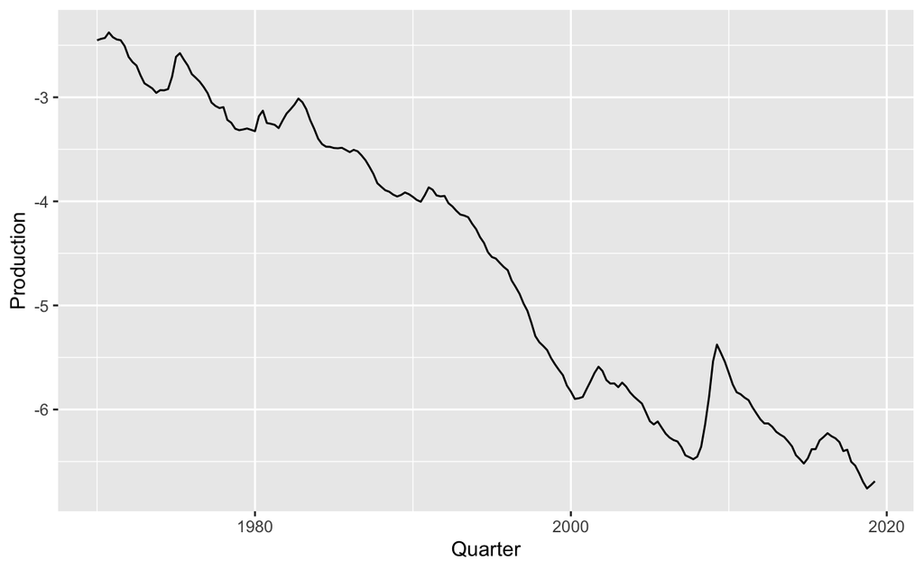

us_change_taxa_variacao_numero_indice %>% tibble::as.tibble() %>% ggplot( aes(x = Quarter, y = Savings) ) + geom_line()

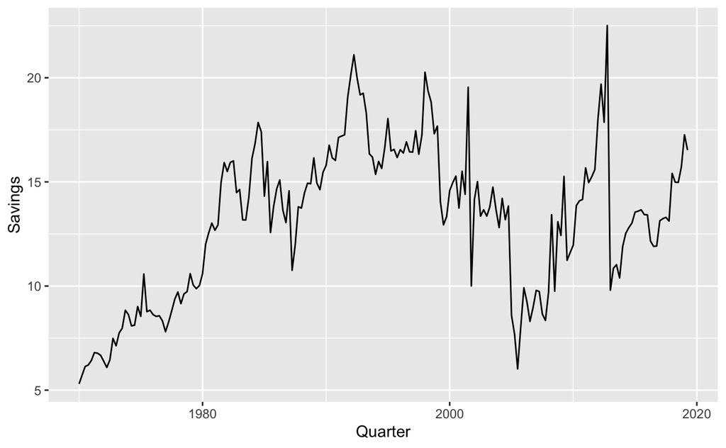

us_change_taxa_variacao_numero_indice %>% tibble::as.tibble() %>% ggplot( aes(x = Quarter, y = Unemployment) ) + geom_line()

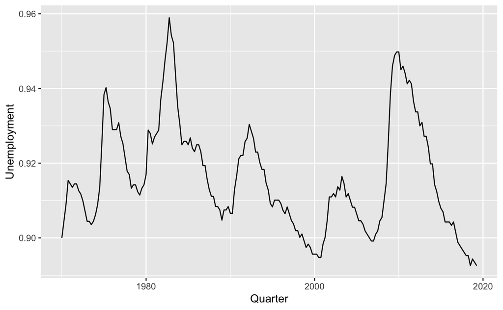

4. A partir das visualizações obtidas no item anterior, que tipo de aprendizado você consegue extrair acerca de
1. evolução das variáveis ao longo do tempo e

RESPOSTAS = - O consumo e a renda aumentarao ao longo das décadas - A produção diminuiu ao longo dos anos - Resumo: - menos desemprego = mais consumo - mais desemprego = menos produção - mais receita = mais poupança - mais produção = menos desemprego …

2. das correlações nas dinâmicas das diversas variáveis?

5. Você consegue identificar, visualmente, alguns movimentos bruscos/atípicos/anômalos na evolução das séries? Tente destacar tais pontos nos gráficos construídos anteriormente. A quais eventos concretos esses momentos atípicos estão relacionados?

RESPOSTAS = - 2001 (ataques terroristas ao WTC): - A produção aumentou logo após - 2008/2009 (crise do subprime): - O consumo diminuiu por cerca de 1 ano - A produção aumentou logo após